# Survey data in R

## Setup

- If you don’t have it already, get the Stata formatted version of the ANES data.
- Run `install.packages(c("srvyr", "survey", "haven", "labelled"))`

## Setup

Once you’ve got the packages installed, and the data downloaded, you can use the code below to import/cleanup the ANES 2024 data:

```r
library(tidyverse)
library(gtsummary)
library(gt)
library(survey)
library(srvyr)
fname<-here::here("data", "anes_timeseries_2024_stata_20260519.zip")
missing<-c("-9. Refused", "-8. Don't know","-4. Error", "-1. Inapplicable" )


anes  <- haven::read_dta(fname)|>
  # converting feeling thermometer questions to numeric
  mutate(across(c(V241156:V241168,
                  V241712:V241720,
                  V242125:V242156,
                  V242514:V242518
                  ),  .fns=~if_else(.x>=0 & .x<=100, as.numeric(.x), NA)))|>
  # converting all other variables to factors
  as_factor()



# getting the list of question labels
question_labels<-lapply(anes, function(x) attr(x, "label"))

# recoding some missing values to explicit NAs
anes<-anes|>
  filter(V240002c == "2. Completed pre and post-election interviews")|>
  mutate(across(where(is.factor),
                .fns=~fct_collapse(.x, "Missing" = missing)|>
                  fct_recode(NULL = "Missing")|>
                  fct_drop()))|>
  drop_na(V240108b)

# re-attaching the variable labels (these get lost in some of the recoding)
labelled::var_label(anes)<-question_labels
```

## Note on the setup

- We previously used .csv formatted files, but we’re using a file with the `.dta` extension for this class.
- `.dta` is the format used by Stata software. Stata formatted files have some additional features that a .csv can’t have. Most importantly, they can include a question label and value labels for each variable.
- This mainly means that we don’t have to recode *as much* to run analyses.

## Reading methodology documents

### What we need

You’ll always need to identify the weighting variable. If you can’t find this, then none of this other advice applies.

### What we need

Other than weights, there are three additional features than *might* be present depending on the survey:

- **Primary Sampling Unit (PSU)**: in clustered samples, the PSU indicates the first “clustering” characteristic sampled. Note that many surveys have multiple stages of clustering, so there can be secondary or tertiary sampling units as well, but these may not be reported.
- **Strata IDs**: Surveys that use stratified samples will often include a unique identifier for each strata.
- **Target population size** some surveys will include a rough estimate of the size of their target population. Where this is included, you can use it to apply the finite population correction.

### The 2024 ANES

The 2024 ANES used multiple modes, sub-samples, and rounds with different response rates and sampling strategies.

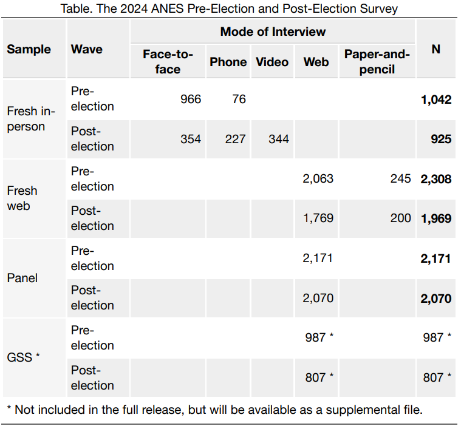

ANES 2024 User Guide (page 9)

### The 2024 ANES

That means we’ll need to select different weights depending on the questions we’re analyzing.

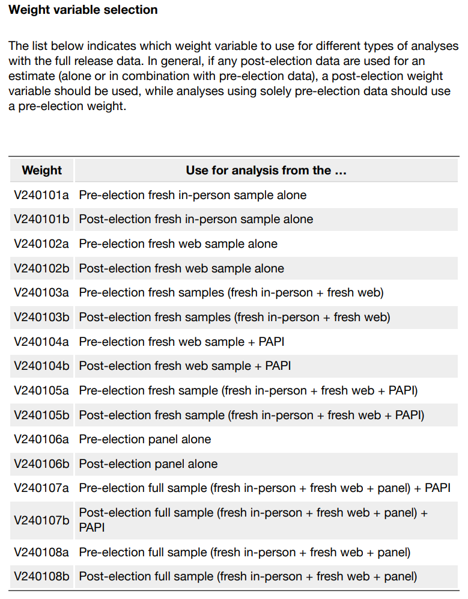

ANES 2024 User Guide (page 12)

### The 2024 ANES

I’m interested in variables from the post-election round, and I want to include everyone who answered the question, so I’ll use the full sample weights.

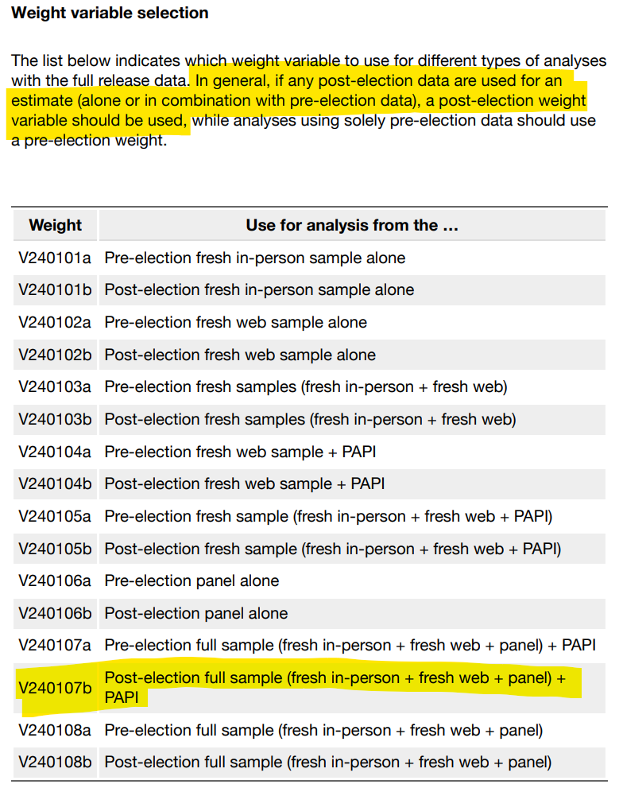

ANES 2024 User Guide (page 12)

### The 2024 ANES

I also need to use different strata and PSU variables for different subsamples. The user guide has another table I can consult to the get those variable names:

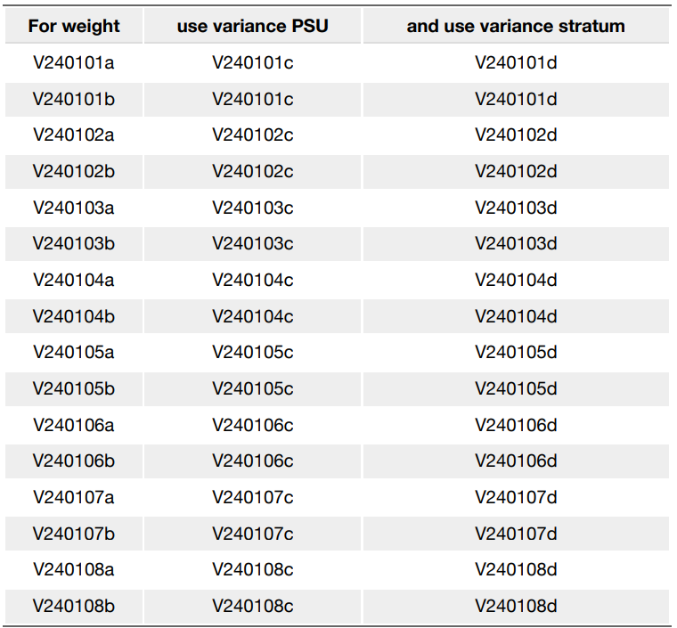

ANES 2024 User Guide (page 13)

### The 2024 ANES

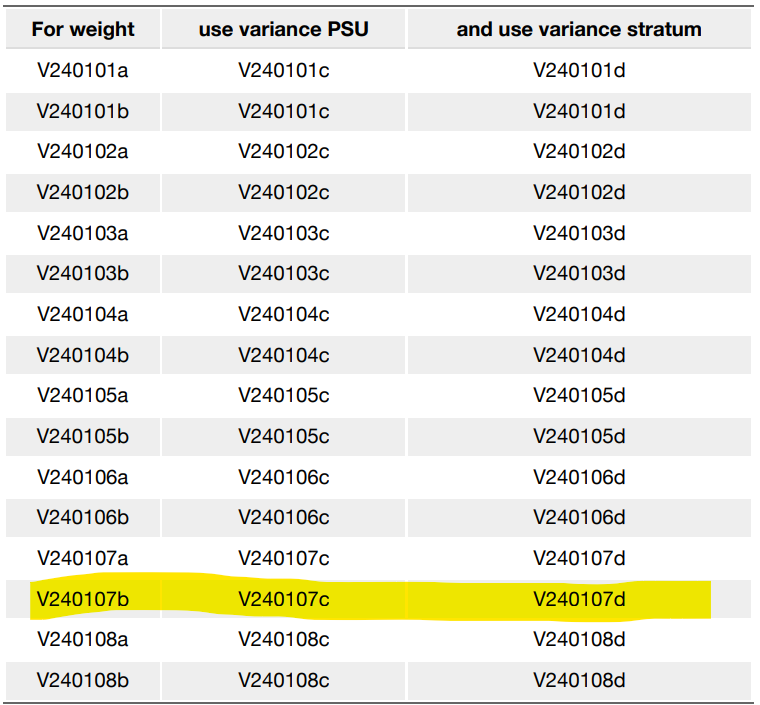

ANES 2024 User Guide (page 13)

### Weighted proportions in R

If we’re just interested in calculating simple weighted proportions, averages, or counts, we can just use the `weight` variable alone.

Instead of:

$$\frac{\sum{y_i}}{n}$$

We calculate a weighted proportion or average:

$$\frac{\sum{y_i \times w_i}}{\sum{w_i}}$$

### Weighted proportions in R

```r
question<-"In the past 12 months: have you joined a protest march, rally, or demonstration?"
anes |>
  as_factor()|>
  mutate(protest = V242029) |>
  drop_na(V240107b, protest)|>
  group_by(protest)|>
  summarize( n = n(),
             weighted.n = sum(V240107b)
             )|>
  mutate(percent = n/sum(n),
         weighted.percent = weighted.n/sum(weighted.n)
         )
```

```
# A tibble: 2 × 5
  protest                                  n weighted.n percent weighted.percent
  <fct>                                <int>      <dbl>   <dbl>            <dbl>
1 1. Have done this in past 12 months    170       165.  0.0357           0.0349
2 2. Have not done this in the past 1…  4590      4567.  0.964            0.965
```

### Weighted proportions in R

However, as with clustering and stratification, weighting changes the variance of our estimates.

That’s because this:

$$\frac{\sum{y_i \times w_i}}{\sum{w_i}}$$

…is a ratio of two random variables.

These calculations get especially tricky when we’re using all three strategies together, which is why we use specialized packages.

### Two common methods for complex variance calculation

- By default, most survey analysis packages will use a **Taylor Series Approximation** to calculate variance.
- This only requires us to know the weights, strata, and cluster IDs, and the calculation is very fast.

### Two common methods for complex variance calculation

Some surveys will provide something called **replicate weights** instead of supplying strata and cluster IDs.

### Two common methods for complex variance calculation

- Replicate weights are a matrix of size $k \times n$, where $k$ is an arbitrary number of replicates (usually 100 or more) and $n$ is the sample size.
- To use a replicate weight, we would calculate the same weighted statistic $k$ times, then we would calculate the variance by aggregating over the $k$ estimated values.

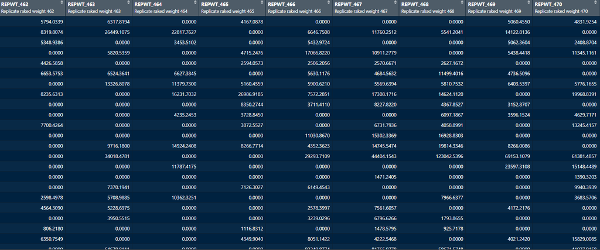

Example of replicate weights on the Pew Religious Landscape study

### R packages for complex surveys

- The R packages `survey` and `srvyr` offer a suite of tools for handling these calculations automatically.
- The `gtsummary` package has some built-in shortcuts for creating formatted tables from survey data.

### Declaring a survey design in srvyr

- To start, we need to convert a conventional tibble or dataframe into a survey design object using `as_survey_design`.
- Once we do this, we can use `srvyr` functions on it and the weights and variance calculations will be performed automatically.

```r
# Example of general syntax:
survey_object <- svy_data |>
  as_survey_design(id = psu,
                   weights = weighting_var,
                   strata = strata_id)
```

### Declaring a survey design in srvyr

- `svy_data` is the original data set
- `id` should be the name of the primary sampling unit variable.
- `weight` should be the name of the weighting variable.
- `strata` should be the strata variable.

The basic syntax will look like this:

```r
survey_object <- svy_data |>
  as_survey_design(id = psu,
                   weights = weighting_var,
                   strata = strata_id)
```

### Declaring a survey design in srvyr

Here’s how we can set this up for the ANES data

- Respondents who skipped the post-election round of the ANES have missing post-election weights. Dropping these avoids an error.
- `nest=TRUE` some relabeling so that the cluster IDs are unique to each strata. (If you need this, R will tell you with an error message.)

```r
anes_survey <- anes |>
  drop_na(V240108b) |>
  as_survey_design(ids = V240108c,
                   weight = V240108b,
                   strata = V240108d,
                   nest = TRUE
                   )
```

Now we should use the `anes_survey` object to analyze the survey.

### Basic steps

- `srvyr` is modeled on the `dplyr` syntax you’ve already used, so things like `group_by` and `summarise` will work more-or-less the same way.
- Most of the important functions will only work when paired with `summarise` and/or `group_by`: `survey_prop` and `survey_mean`

### survey_prop and survey_mean

```r
survey_mean(
   x,
   na.rm = FALSE,
   vartype = c("se", "ci", "var", "cv"),
   level = 0.95,
   proportion = FALSE,
   prop_method = c("logit", "likelihood", "asin", "beta", "mean"),
   deff = FALSE,
   df = NULL,
   ...
)
```

```r
survey_prop(
  vartype = c("se", "ci", "var", "cv"),
  level = 0.95,
  proportion = FALSE,
  prop_method = c("logit", "likelihood", "asin", "beta", "mean"),
  deff = FALSE,
  df = NULL,
  ...
)
```

### survey_prop

You can use `survey_prop` to calculate proportions along levels of a grouping variable.

```r
#V242029: In the past 12 months: have you joined a protest march, rally, or demonstration?
anes_survey|>
  group_by(V242029)|>
  summarise(survey_prop(),      # weighted proportions
            n = unweighted(n()) # unweighted counts
            )
```

```
# A tibble: 3 × 4
  V242029                                         coef    `_se`     n
  <fct>                                          <dbl>    <dbl> <int>
1 1. Have done this in past 12 months         0.0350   0.00364    170
2 2. Have not done this in the past 12 months 0.964    0.00369   4590
3 <NA>                                        0.000856 0.000591     4
```

### survey_prop

`vartype="ci"` will report a 95% confidence interval instead of the standard error:

```r
# In the past 12 months: have you joined a protest march, rally, or demonstration?
anes_survey|>
  group_by(V242029)|>
  summarise(survey_prop(vartype = "ci"),      # weighted proportions
            n = unweighted(n()) # unweighted counts
            )
```

```
# A tibble: 3 × 5
  V242029                                         coef   `_low`  `_upp`     n
  <fct>                                          <dbl>    <dbl>   <dbl> <int>
1 1. Have done this in past 12 months         0.0350   0.0286   0.0429    170
2 2. Have not done this in the past 12 months 0.964    0.956    0.971    4590
3 <NA>                                        0.000856 0.000221 0.00331     4
```

### survey_prop

I can get proportions along multiple categories by adding a second grouping variable.

```r
# V241235: How much do you feel that having elections makes the government pay attention?
# V242029: In the past 12 months: have you joined a protest march, rally, or demonstration?
anes_survey|>
  group_by(V241235, V242029)|>
  summarise(survey_prop(vartype = "ci"),      # weighted proportions
            n = unweighted(n()) # unweighted counts
            )|>
  drop_na()
```

```
# A tibble: 6 × 6
  V241235        V242029                                coef `_low` `_upp`     n
  <fct>          <fct>                                 <dbl>  <dbl>  <dbl> <int>
1 1. A good deal 1. Have done this in past 12 months  0.0438 0.0312 0.0612    64
2 1. A good deal 2. Have not done this in the past 1… 0.956  0.939  0.969   1353
3 2. Some        1. Have done this in past 12 months  0.0282 0.0208 0.0381    78
4 2. Some        2. Have not done this in the past 1… 0.971  0.961  0.978   2310
5 3. Not much    1. Have done this in past 12 months  0.0398 0.0246 0.0638    28
6 3. Not much    2. Have not done this in the past 1… 0.960  0.936  0.975    915
```

### survey_prop

Note that these proportions sum to 1 for the **first** variable listed:

```r
anes_survey|>
  group_by(V241235, V242029)|>
  summarise(survey_prop(vartype = "ci"),
            n = unweighted(n())
            )|>
  drop_na()
```

```
# A tibble: 6 × 6
  V241235        V242029                                coef `_low` `_upp`     n
  <fct>          <fct>                                 <dbl>  <dbl>  <dbl> <int>
1 1. A good deal 1. Have done this in past 12 months  0.0438 0.0312 0.0612    64
2 1. A good deal 2. Have not done this in the past 1… 0.956  0.939  0.969   1353
3 2. Some        1. Have done this in past 12 months  0.0282 0.0208 0.0381    78
4 2. Some        2. Have not done this in the past 1… 0.971  0.961  0.978   2310
5 3. Not much    1. Have done this in past 12 months  0.0398 0.0246 0.0638    28
6 3. Not much    2. Have not done this in the past 1… 0.960  0.936  0.975    915
```

### survey_prop

“about 4.4% of people who think elections make the government pay a good deal of attention have protested in the last 12 months”

```r
anes_survey|>
  group_by(V241235, V242029)|>
  summarise(survey_prop(vartype = "ci"),
            n = unweighted(n())
            )|>
  drop_na()
```

```
# A tibble: 6 × 6
  V241235        V242029                                coef `_low` `_upp`     n
  <fct>          <fct>                                 <dbl>  <dbl>  <dbl> <int>
1 1. A good deal 1. Have done this in past 12 months  0.0438 0.0312 0.0612    64
2 1. A good deal 2. Have not done this in the past 1… 0.956  0.939  0.969   1353
3 2. Some        1. Have done this in past 12 months  0.0282 0.0208 0.0381    78
4 2. Some        2. Have not done this in the past 1… 0.971  0.961  0.978   2310
5 3. Not much    1. Have done this in past 12 months  0.0398 0.0246 0.0638    28
6 3. Not much    2. Have not done this in the past 1… 0.960  0.936  0.975    915
```

### survey_prop

“about 36% of people who have protested in the last 12 months think that elections make the government pay a good deal of attention”

```r
anes_survey|>
  group_by(V242029, V241235)|>
  summarise(survey_prop(vartype = "ci"),
            n = unweighted(n())
            )|>
  drop_na()
```

```
# A tibble: 6 × 6
  V242029                                     V241235   coef `_low` `_upp`     n
  <fct>                                       <fct>    <dbl>  <dbl>  <dbl> <int>
1 1. Have done this in past 12 months         1. A go… 0.356  0.263  0.460    64
2 1. Have done this in past 12 months         2. Some  0.400  0.303  0.506    78
3 1. Have done this in past 12 months         3. Not … 0.244  0.158  0.357    28
4 2. Have not done this in the past 12 months 1. A go… 0.282  0.264  0.302  1353
5 2. Have not done this in the past 12 months 2. Some  0.500  0.479  0.522  2310
6 2. Have not done this in the past 12 months 3. Not … 0.214  0.197  0.231   915
```

### survey_mean

`survey_mean` will report the average for a numeric variable.

```r
# V242141: Feeling thermometer: big business

anes_survey|>
  summarise(`big_business_therm` = survey_mean(V242141 ,
                                               vartype = "ci",
                                               na.rm=T),
            n = unweighted(n()) # unweighted counts
            )
```

```
# A tibble: 1 × 4
  big_business_therm big_business_therm_low big_business_therm_upp     n
               <dbl>                  <dbl>                  <dbl> <int>
1               44.4                   43.5                   45.4  4764
```

### survey_mean

Pairing `survey_mean` with `group_by` will return an average for each value of the grouping variable:

```r
# V241497 : Does R belong to a labor union?
# V242141: Feeling thermometer: big business
anes_survey |>
  group_by(V241497) |>
  summarise(
    `big_business_therm` = survey_mean(V242141 , vartype = "ci", na.rm = T),
     n = unweighted(n()) # unweighted counts
  ) |>
  drop_na()
```

```
# A tibble: 2 × 5
  V241497 big_business_therm big_business_therm_low big_business_therm_upp     n
  <fct>                <dbl>                  <dbl>                  <dbl> <int>
1 1. Yes                41.5                   38.9                   44.2   664
2 2. No                 44.9                   43.9                   46.0  4076
```

### Difference of means test

We can use the `svyttest` function from the `survey` package to calculate a weighted difference of means test for a complex sample.

### Difference of means test

Does union membership have a statistically significant impact on feelings towards big business?

```r
library(survey)  # svyttest is part of the survey package, rather than srvyr
svyttest(formula = V242141 ~ V241497 ,
         design = anes_survey,
         na.rm=T
         )
```

```
    Design-based t-test

data:  V242141 ~ V241497
t = 2.264, df = 1745, p-value = 0.0237
alternative hypothesis: true difference in mean is not equal to 0
95 percent confidence interval:
 0.4509144 6.2946857
sample estimates:
difference in mean
            3.3728
```

### Formatting output

```r
anes_survey |>
  group_by(V241497) |>
  summarise(
    `big_business_therm` = survey_mean(V242141 , vartype = "ci", na.rm = T),
     n = unweighted(n()) # unweighted counts
  ) |>
  drop_na()
```

```
# A tibble: 2 × 5
  V241497 big_business_therm big_business_therm_low big_business_therm_upp     n
  <fct>                <dbl>                  <dbl>                  <dbl> <int>
1 1. Yes                41.5                   38.9                   44.2   664
2 2. No                 44.9                   43.9                   46.0  4076
```

### Using gtsummary

`gtsummary` has some additional functions for working with survey data objects. The `tbl_svysummary` function will automatically report weighted proportions and variances for survey objects:

```r
anes_survey|>
  tbl_svysummary(include =V242029)|>
  # add confidence intervals
  add_ci()
```

| **Characteristic** | **N = 4,764**<sup>1</sup> | **95% CI** |
| --- | --- | --- |
| POST: Has R in past 12 months: joined a protest march, rally, or demonstration |  |  |
| 1. Have done this in past 12 months | 167 (3.5%) | 2.9%, 4.3% |
| 2. Have not done this in the past 12 months | 4,593 (96%) | 96%, 97% |
| Unknown | 4 |  |

<sup>1</sup> n (%)  
Abbreviation: CI = Confidence Interval

### Using gtsummary

Using `add_p()` on a cross tab will automatically calculate a $\chi^2$ p-value, which gives us a probability of seeing these disproportionalities if the row and column variables are unrelated:

```r
anes_survey|>
  drop_na(V241235, V241407)|>
  tbl_svysummary(include =V241235, by =V241407

                 )|>
  add_p()|>
  modify_spanning_header(
    all_stat_cols() ~ "PRE: Does R side more with Israelis, Palestinians or neither?"
)
```

| **Characteristic** | PRE: Does R side more with Israelis, Palestinians or neither? **1. Israelis** N = 1,364<sup>1</sup> | PRE: Does R side more with Israelis, Palestinians or neither? **2. Palestinians** N = 637<sup>1</sup> | PRE: Does R side more with Israelis, Palestinians or neither? **3. Both equally** N = 933<sup>1</sup> | PRE: Does R side more with Israelis, Palestinians or neither? **4. Neither** N = 1,759<sup>1</sup> | **p-value**<sup>2</sup> |  |
| --- | --- | --- | --- | --- | --- | --- |
| PRE: Elections make government pay attention |  |  |  |  |  | <0.001 |
| 1. A good deal | 396 (29%) | 202 (32%) | 364 (39%) | 384 (22%) |  |  |
| 2. Some | 702 (51%) | 332 (52%) | 432 (46%) | 870 (49%) |  |  |
| 3. Not much | 265 (19%) | 103 (16%) | 138 (15%) | 504 (29%) |  |  |

<sup>1</sup> n (%)  
<sup>2</sup> Pearson’s X^2: Rao & Scott adjustment

### Using gtsummary

This also works for continuous variables:

```r
anes_survey|>
  drop_na(V242141, V241497)|>
  tbl_svysummary(include =V242141,  by= V241497,
                 label = list(V242141= "Feeling thermometer towards big business")

                 )|>
  modify_spanning_header(
    all_stat_cols() ~ "Do you or anyone else in this household belong to a labor union or to
an employee association similar to a union?"
  )
```

| **Characteristic** | Do you or anyone else in this household belong to a labor union or to an employee association similar to a union? **1. Yes** N = 689<sup>1</sup> | Do you or anyone else in this household belong to a labor union or to an employee association similar to a union? **2. No** N = 3,949<sup>1</sup> |
| --- | --- | --- |
| Feeling thermometer towards big business | 40 (30, 50) | 50 (30, 60) |

<sup>1</sup> Median (Q1, Q3)

### Using gtsummary

```r
anes_survey|>
  drop_na(V242141, V241497)|>

  tbl_svysummary(include =V242141,  by= V241497,
                 label = list(V242141= "Feeling thermometer towards big business")

                 )|>
  modify_spanning_header(
    all_stat_cols() ~ "Do you or anyone else in this household belong to a labor union or to
an employee association similar to a union?"
  )|>
  add_p()
```

| **Characteristic** | Do you or anyone else in this household belong to a labor union or to an employee association similar to a union? **1. Yes** N = 689<sup>1</sup> | Do you or anyone else in this household belong to a labor union or to an employee association similar to a union? **2. No** N = 3,949<sup>1</sup> | **p-value**<sup>2</sup> |  |
| --- | --- | --- | --- | --- |
| Feeling thermometer towards big business | 40 (30, 50) | 50 (30, 60) |  | 0.006 |

<sup>1</sup> Median (Q1, Q3)  
<sup>2</sup> Design-based KruskalWallis test

## Using gtsummary

However, we can use `add_difference()` to calculate a difference of means test, and we can add this argument: `statistic = V242141 ~ "{mean} ({sd})"` to show the mean and standard deviation instead of the median.

```r
anes_survey|>
  drop_na(V242141, V241497)|>

  tbl_svysummary(include =V242141,  by= V241497,
                 label = list(V242141= "Feeling thermometer towards big business"),
                 statistic = V242141 ~ "{mean} ({sd})"

                 )|>
  modify_spanning_header(
    all_stat_cols() ~ "Do you or anyone else in this household belong to a labor union or to
an employee association similar to a union?"
  )|>
  add_difference()
```

| **Characteristic** | Do you or anyone else in this household belong to a labor union or to an employee association similar to a union? **1. Yes** N = 689<sup>1</sup> | Do you or anyone else in this household belong to a labor union or to an employee association similar to a union? **2. No** N = 3,949<sup>1</sup> | **Difference**<sup>2</sup> | **95% CI**<sup>2</sup> | **p-value**<sup>2</sup> |  |  |  |
| --- | --- | --- | --- | --- | --- | --- | --- | --- |
| Feeling thermometer towards big business | 42 (23) | 45 (23) |  |  |  | 3.4 | 0.45, 6.3 | 0.024 |

<sup>1</sup> Mean (SD)  
<sup>2</sup> Design-based t-test  
Abbreviation: CI = Confidence Interval

## Extra code: replicate weights

Here’s an example of how you would set this up if this survey used replicate weights:

```r
# reading in an example file with replicate weights
wgts<-read_csv('https://raw.githubusercontent.com/Neilblund/SDSB340-Fall-2026/refs/heads/master/Data/anes_repwts.csv')

anes_combined<-anes|>
  drop_na(V240108b)|>
  left_join(wgts, by='V240001') # matching on respondent IDs

anes_replicate<-anes_combined|>
  as_survey_rep(repweights = starts_with("REPWT"), # all columns that start with "REPWT" are replicate weights
                weights = V240108b,                # main weights for point estimates
                type = 'bootstrap',                 # survey documentation should tell you the type of replicate weights to declare
                mse = TRUE
                )
```

from here, survey analysis is identical to using the regular setup(and results should be very similar to what you get using anes_survey)

```r
anes_replicate|>
  summarise(
    `big_business_therm` = survey_mean(V242141 , vartype='var', na.rm = T),
  )
```

```
# A tibble: 1 × 2
  big_business_therm big_business_therm_var
               <dbl>                  <dbl>
1               44.4                  0.372
```

## Extra code: replicate weights

This is actually just calculating the same statistic for each replicate weight, and the calculating the variance around the point estimate:

```r
index<-which(!is.na(anes_combined$V242141))  # non-missing values of the big business feelings
y <- anes_combined$V242141[index]
weights<-wgts[which(!is.na(anes_combined$V242141)) ,2:ncol(wgts)] # all the weights for non-missing values
est<-weighted.mean(y, anes_combined$V240108b[index], na.rm=T) # weighted estimate

df<-(ncol(weights)-1) # number of replicates minus 1
rep_means<-numeric(length=ncol(weights)) # empty vector for replicates

for(i in 1:ncol(weights)){

  w <- weights[[i]]
  # estimating a weighted mean & storing the result
  rep_means[i] <- sum(y * w) / sum(w)
}


rep_var<- sum((est - rep_means) ^2) / df  # variance around est
rep_var # this should match the variance from srvyr
```

```
[1] 0.3716941
```